# População

```r
require(ggplot2)
require(gridExtra)
```

## Uma espécie, uma população

População pode ser definida como um conjunto de indivíduos de uma mesma espécie que vive em uma determinada área. Imagine uma área que possui árvores de apenas uma espécie, e todas elas foram localizadas, numeradas e mapeadas. O número e localização de cada uma das árvores mapeadas foram refistradas numa planilha.

```r
head(comunidade)
```

|  | especie | coordx | coordy |
| --- | --- | --- | --- |
| 1 | 1 | 72.80664679 | 9.178517 |
| 2 | 1 | 33.80916992 | 93.216648 |
| 3 | 1 | 0.08259204 | 54.364949 |
| 4 | 1 | 47.30349875 | 15.669387 |
| 5 | 1 | 20.98704665 | 58.493648 |
| 6 | 1 | 38.30127052 | 97.046752 |

Outra forma de apresentar os dados registrados e por meio de um gráfico em que cada ponto representa um dos indivíduos. Os eixos representam as coordenadas dos indivíduos na área amostrada.

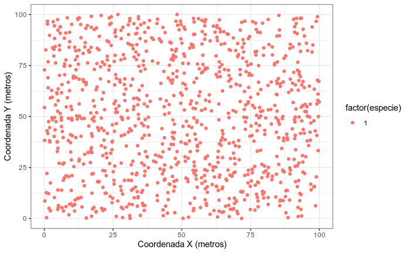

```r
ggplot(comunidade, aes(coordx, coordy, col = factor(especie))) +
  geom_point() +
  xlab('Coordenada X (metros)') +
  ylab('Coordenada Y (metros)') +
  theme_bw()
```

## De população para comunidade

Mas uma floresta nativa não é formada apenas pela população de espécie, mas por populações de várias espécies, que cohabitam a mesma área. Nas comunidades, as diferentes populações interagem das mais variadas maneiras. Essas interações, também chamadas de relações ecológicas que podem ser interespecíficas ou intraespecíficas.

```r
head(comunidade2)
```

|  | especie | coordx | coordy |
| --- | --- | --- | --- |
| 1 | 6 | 62.87400 | 26.92711 |
| 2 | 2 | 91.51299 | 93.65314 |
| 3 | 5 | 92.67213 | 78.41964 |
| 4 | 4 | 23.63750 | 32.96940 |
| 5 | 4 | 60.60472 | 79.86133 |
| 6 | 4 | 75.82137 | 22.98036 |

A representação gráfica de uma comunidade se torna muito mais complexa que a representação gráfica de uma população. Numa mesma área, antes dominada por apenas uma espécíe, agora é divida por indivíduos de várias espécies. Outra forma de apresentar os dados registrados e por meio de um gráfico em que cada ponto representa um dos indivíduos. Os eixos representam as coordenadas dos indivíduos na área amostrada.

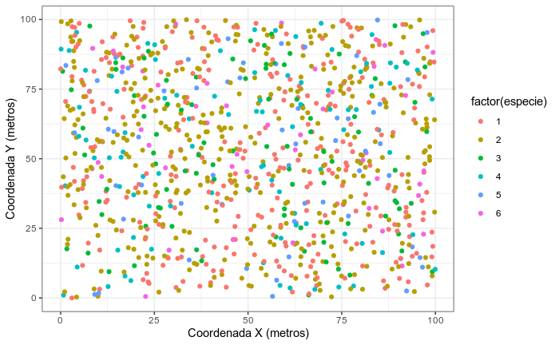

```r
ggplot(comunidade2, aes(coordx, coordy, col = factor(especie))) +
  geom_point() +
  xlab('Coordenada X (metros)') +
  ylab('Coordenada Y (metros)') +
  theme_bw()
```

## Índice de diversidade

Duas áreas foram estudadas, levantando todos os indivíduos existentes nelas. Cada indivíduos foi identificado em nível de espécie, e sua posição no espaço foi registrado. Ao colocar lado a lado o mapa dos indivíduos das duas áreas estudadas qual delas está mais organizada? Como é possível medir a organização de uma comunidade? Qual a característica que reflete esta organização?

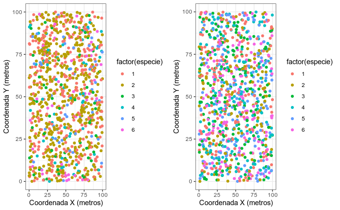

```r
c1 = ggplot(comunidade3, aes(coordx, coordy, col = factor(especie))) +
  geom_point() +
  xlab('Coordenada X (metros)') +
  ylab('Coordenada Y (metros)') +
  theme_bw()

c2 = ggplot(comunidade4, aes(coordx, coordy, col = factor(especie))) +
  geom_point() +
  xlab('Coordenada X (metros)') +
  ylab('Coordenada Y (metros)') +
  theme_bw()

grid.arrange(c1, c2, ncol=2)
```

Uma das formas de comparar a comunidade de duas áreas é usando índices de diversidade. O mais conhecido deles é índice de Shannon.

$$H = - \sum_{i=1}^{S} p_i ln(p_i)$$

Aplicando o índice de Shannon para a primeira área obtem-se o valor de:

```r
termo1 = table(comunidade3$especie)/length(comunidade3$especie)
termo2 = log(table(comunidade3$especie)/length(comunidade3$especie))
H1 = -1 * sum(termo1 * termo2)
H1
```

```
[1] 1.326623
```

```r
termo1 = table(comunidade4$especie)/length(comunidade4$especie)
termo2 = log(table(comunidade4$especie)/length(comunidade4$especie))
H2 = -1 * sum(termo1 * termo2)
H2
```

```
[1] 1.789731
```

Mas se ambas as áreas possuem 6 espécies, porque os valores do índice de Shannon possuem valores diferentes?

Isto ocorre pois o conjunto de populações de cada uma das áreas formam uma comunidade que não se distribuem da mesma forma. Na primeira área, a população da espécie 2 é muito maior que as populações das demais espécies. Já na área 2, todas as populações aparentam ter um número muito parecido de indivíduos.

Analisando os dados coletados de cada uma das áreas, é possível perceber que de fato a área 1 é dominada pela espécie 2.

```r
table(comunidade3$especie)
```

```
  1   2   3   4   5   6
305 487  53  56  55  44
```

Enquanto que a área dois, todas as populações apresentam valores populacionais muito parecidos.

```r
table(comunidade4$especie)
```

```
  1   2   3   4   5   6
176 145 175 165 172 167
```

Logo, quanto maior o número de espécie e quanto mais balanceadas o tamanho das populações, maior o valor do índice de diversidade.